# Statistical learning and data analysis - Lab No. 3

Bar Weinstein and Hananel Giat

June 12, 2019

# Question 1 - Theory

## 1.1

$$Eop = E[Err_{in}- \overline{err}(\hat{y})|X_{1}....X_n]$$

while,
$$Err_{in} = {\frac{1}{n}}\sum E_{y^{*}|X=x_i}[(y^{*}-\hat{y})^2|T]$$
$$\overline{err}(\hat f) = {\frac{1}{n}}\sum (y_i -\hat{y})^2$$
while $y^{*}$ is the new $y$ values gathered from the original $X$ sample with added variation to $X$ values. so we get that
$$E_y[\frac{1}{n}\sum E_{y^{*}}[(y_i^*-\hat{y_i})^2]-\frac{1}{n}\sum(y_i-\hat{y_i})^2]=$$
$$=\frac{1}{n}\sum E_y[E_{y^*}[y_{i}^{*^{2}}-2\hat{y_i}y^*+\hat{y_i}]-y_i^2+2\hat{y_i}y_i-\hat{y_i}^2]=$$
$$= \frac{1}{n}\sum(E_yE_{y^*}[y_{i}^{*^{2}}]-2E_yE_{y^*}[\hat{y_i}y_i^*]+E_yE_{y^*}[\hat{y}^2]-E_y[y_i^2]+2E_y[\hat{y_i}y_i]-E_y[\hat{y}^2])$$

but because the added variation has zero mean we get that
$$E_yE_{y^*}[y_{i}^{*^{2}}]=E_y[y_i^2]$$
so
$$Eop = \frac{1}{n}\sum(-2E_yE_{y^*}[\hat{y_i}y_i^*]+E_yE_{y^*}[\hat{y}^2]+2E_y[\hat{y_i}y_i]-E_y[\hat{y}^2])$$

but because $y_i^*$ and $\hat{y_i}$ are independent, $E_yE_{y^*}[\hat{y}^2] = E_y[\hat{y}^2]$ so,
$$= \frac{1}{n}\sum(-2E_yE_{y^*}[\hat{y_i}y_i^*]+2E_y[\hat{y_i}y_i])$$

and,
$$-2E_yE_{y^*}[\hat{y_i}y_i^*]= -2E_Y[\hat{y_i}]E_yE_{y^*}[y_i^*] = -2E_y[\hat{y_i}]E_y[y_i]$$
so we have,
$$= \frac{1}{n}\sum(2E_y[\hat{y_i}y_i]-2E_y[\hat{y_i}]E_y[y_i]])=\frac{2}{n}\sum(E_y[\hat{y_i}y_i]-E_y[\hat{y_i}]E_y[y_i]])=\frac{2}{n}\sum(cov(y_i,\hat{y_i}))$$

## 1.2

Need to prove : $Eop = \frac{2 \sigma^2}{n}trace(W)$

we know that :
$$Eop = {\frac{2}{n}}\sum cov(y_i,\hat{y_i})$$

$${\frac{2}{n}}\sum cov(y_i,\hat{y_i}) = \frac{2}{n}\sum cov(y_i,w_iy_i) =$$
$$=\frac{2}{n}\sum cov(f(x_i) + \epsilon_i,w_i(f(x_i)+\epsilon_i)) =$$
but $f(x_i)$ and $w_i\cdot f(x_i)$ are independent for $\forall i$ and each of them is independent of $\epsilon_i$,
$$=\frac{2}{n}\sum cov( \epsilon_i,w_{ii}\epsilon_i) =$$
$$=\frac{2}{n}\sum w_{ii}cov( \epsilon_i,\epsilon_i) =$$
$$=\frac{2}{n}\sum w_{ii}var( \epsilon_i) = \frac{2}{n}\sum w_{ii}\sigma^2=$$
$$=\frac{2 \sigma^2}{n}trace(W)$$

## 1.3

Need to prove : that generalized degrees of freedom in OLS estimator under the assumption predictors that matrix X is full rank generalized degrees of freedom defined: $df = \frac{1}{\sigma^2}\sum cov(y_i,\hat{y_i})$
$$df = \frac{1}{\sigma^2}\sum cov(y_i,\hat{y_i}) = \frac{1}{\sigma^2} \frac{n}{2} \frac{2}{n}\sigma^2 trace(W) = trace(W)$$
we now that : $\hat{\beta} = (X^TX)^{-1}X^Ty$

so we can write the fitted values as :
$$\hat{\mu} = X\hat{\beta}= (X(X^TX)^{-1}X^T)y$$

when :
$$(X(X^TX)^{-1}X^T) = W$$

so :
$$trace(W) = trace((X(X^TX)^{-1}X^T))=$$

$$= trace(X^TX(X^TX)^{-1})$$
becuse :
$$trace(AB) = trace(BA)$$
$$=>trace(X^TX(X^TX)^{-1}) = trace(I_p) = p$$

# Question 2 - 1-dimensional function

## Data Sample

```r
data_sample = function(n=NULL,lambda,x=NULL){ # 'n' for sample size, 'lambda' is sin() coef, and 'x' is vector of choice
  if(is.null(x)){
    if(is.null(n)){return(print("Error: Insert x vector or n dimension!!!"))}
    x = runif(n,min = -2, max = 2)
  }
  n = ifelse(is.null(n),length(x),n)
  output = list()
  output$y = c(sin(lambda*x) + (0.3*(x^2)) + ((x-0.5)/3)^3 + rnorm(n,mean = 0, sd = sqrt(0.3)))
  output$x = c(x)
  return(output)
}
```

## Kernel Regression Function

```r
gauss_kernel = function(X,xtrain,h){ # Normal(0,1) Kernel, 'X' is the new values to predict
  kernel = dnorm((xtrain-X)/h, mean = 0 ,sd = 1)
  return(kernel) #return kernel vec not the mean of the kernel
}

kernel_reg = function(x_train,y_train,x_test,h){ # Nadaraya–Watson kernel
  if(h <0){return(print("Error: bandwidth is negative! ... Insert a positive bandwidth"))}
  y_hat = c()
  for (i in 1:length(x_test)){
    kernel_vec = gauss_kernel(X=x_test[i],xtrain = x_train,h = h)
    y_hat[i] = ifelse(sum(kernel_vec) == 0, NA ,sum(kernel_vec*y_train) / sum(kernel_vec))#if x_test is out of range return NA
  }
  return(y_hat)
}
```

## Kernel Regression Simulation

**Simulation outline:**

For each $bindwidth \in [0.1,3]$, $\lambda \in \{1.5,5\}$, $n \in \{50,200\}$ we did the following:

Now For the results

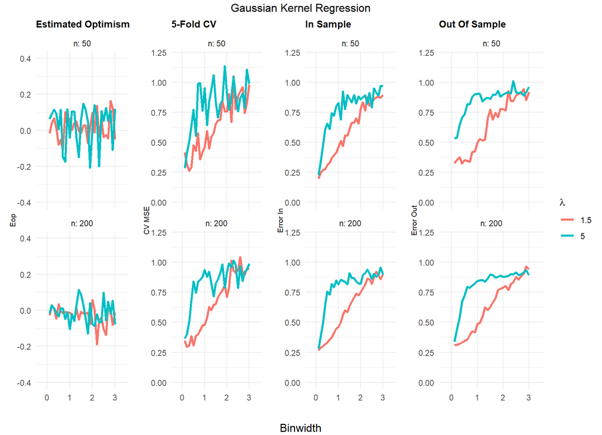

## Quadratic Model

Now we’re going to repeat the same steps but using Quadratic Regression of the form:

$$\hat{y} = b_1 + b_2x + b_3x^2$$

We Estimated the parameters using Ordinary Least Squares (OLS).

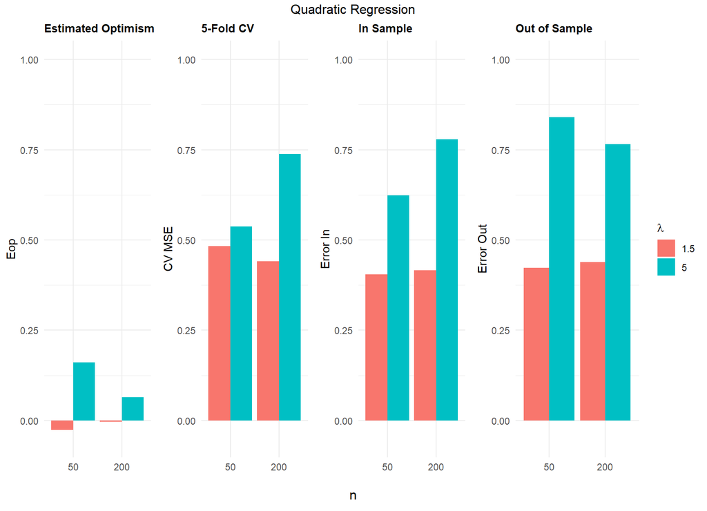

**Simulation Conclusion**

After conducing a thorough simulation to test 2 different models using a known data generating process and different error measures we’ve reached a conclusive conclusions about the optimal parameters fit (of the given data of course) which is a smaller $\lambda$ values (less weight to $sin$ function cyclicity), smaller Binwidth while using Kernel Regression, larger sample size that reduce the amount of noise And the usefulness of using Cross-Validation as an approximation of model fit.

# Question 3 - fMRI Data

## Prediction model

We’re going to fit a linear regression model for each Voxel but because at the given data there is 10921 features and only 1750 observations we cannot use a simple OLS linear regression ($p >> n$). To manage the dimension problem we’re going to use a regularized regression, i.e. we’re going to use *Elastic Nets* regression with balanced weights (0.5 for each norm) and standardized features. We’re going to estimate the parameters using the above formula:

$$\hat{\beta} = argmin_x({\|y - X\cdot\beta\|}^2+{\lambda}_2\cdot{\|\beta\|}^2+{\lambda}_1\cdot{\|\beta\|}_1)$$

And we’ll estimate the optimal $\lambda$ for each *Voxel* using 5-fold Cross-Validation and choosing the $\lambda$ that minimize the *CV MSE*. We’re going to split the `feature_train` data to *train* and *test* partitions by uniformly choosing 70% as *train* set and going to check the *test MSE* as well. Because we’re using a regression with penalty we expect that a few features is going to be excluded (i.e. their coefficients values will be zero.).

Now for the results

| Voxel | Lambda | Train CV MSE | # Features | Test MSE |
| --- | --- | --- | --- | --- |
| Voxel 1 | 0.12124 | 0.69942 | 84 | 0.74157 |
| Voxel 2 | 0.14461 | 0.65677 | 82 | 0.66459 |
| Voxel 3 | 0.14432 | 0.69964 | 69 | 0.73639 |
| Voxel 4 | 0.13069 | 0.74173 | 62 | 0.75087 |
| Voxel 5 | 0.12306 | 0.76273 | 90 | 0.72359 |
| Voxel 6 | 0.18821 | 0.93144 | 15 | 0.89770 |
| Voxel 7 | 0.11343 | 0.83129 | 117 | 0.91705 |
| Voxel 8 | 0.13032 | 0.91803 | 63 | 0.97086 |
| Voxel 9 | 0.17794 | 0.95136 | 23 | 0.97910 |
| Voxel 10 | 0.15530 | 0.95780 | 43 | 0.88684 |
| Voxel 11 | 0.21644 | 0.99242 | 2 | 1.01063 |
| Voxel 12 | 0.13913 | 0.98831 | 45 | 1.02456 |
| Voxel 13 | 0.20077 | 0.99342 | 3 | 1.00680 |
| Voxel 14 | 0.21179 | 0.96325 | 1 | 1.08205 |
| Voxel 15 | 0.21948 | 1.00091 | 1 | 0.99580 |

1. Few *Voxels* has only 1 Feature left (and most of them is the intercept)
2. The lowest *Test MSE* *Voxel* is Voxel 2 which have the best (lowest) *Test MSE* and *CV MSE*

## Analysis

As mentioned, *Voxel 2* have the best fit so we’re going to analyse the results on him.

**First** lets see the *Elastic Nets* model $\lambda$ plots to show the model fit process

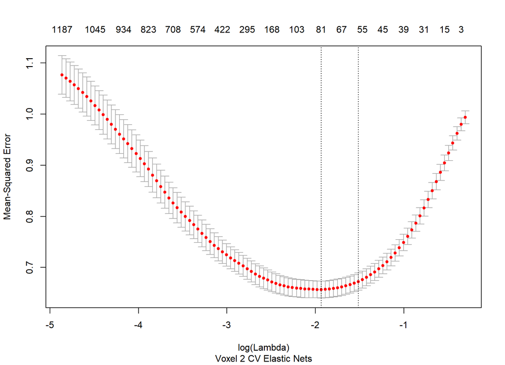

Interestingly the $\lambda\sim MSE$ is convex and the optimal $\lambda$, in terms on minimize the MSE, is 0.144606.

**Second**, we’re going to inspect the most important non-zero variables at the train feature set by using the following metric:

$$Importance(x_i) := SD(x_i)\cdot|\beta_i|$$

We expect that most $\beta$ values will be around the same scale because we standardized the features values (by column) so we Features with high $\beta$ and high Standard-Deviation (high dispersion) will be marked as important.

Lets see some of the important Features

Voxel 2 Important Features

| Feature | Feature_Importance |
| --- | --- |
| Feature 1746 | 0.06122 |
| Feature 6658 | 0.06053 |
| Feature 7165 | 0.04417 |
| Feature 6649 | 0.04358 |
| Feature 6908 | 0.04009 |
| Feature 6652 | 0.03962 |
| Feature 6655 | 0.03549 |
| Feature 7432 | 0.03457 |
| Feature 6877 | 0.03315 |
| Feature 1741 | 0.03157 |

Each Feature generated using a combination of *Wavelet Filter* and Image features, hence each Feature represent a different aspect of the image. Lets observe the Features of the top 3 Features (by the above metric).

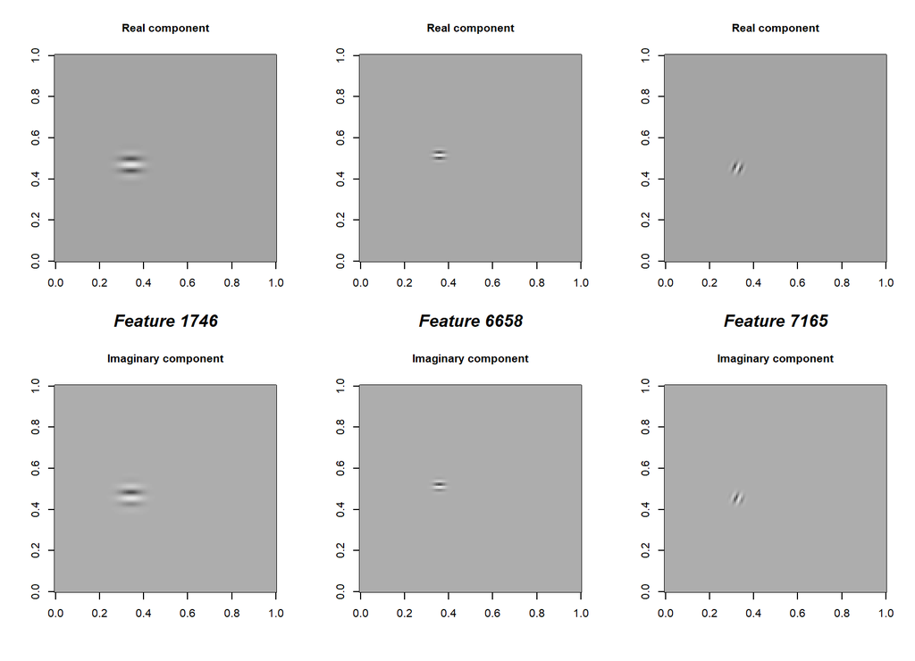

Its not that clear which aspect of the image each feature represent.

**Third** we want to check if the association between the Voxel and Features is Linear or perhaps Quadratic, to check we’re going to view the association between the most important variable and Voxel 2:

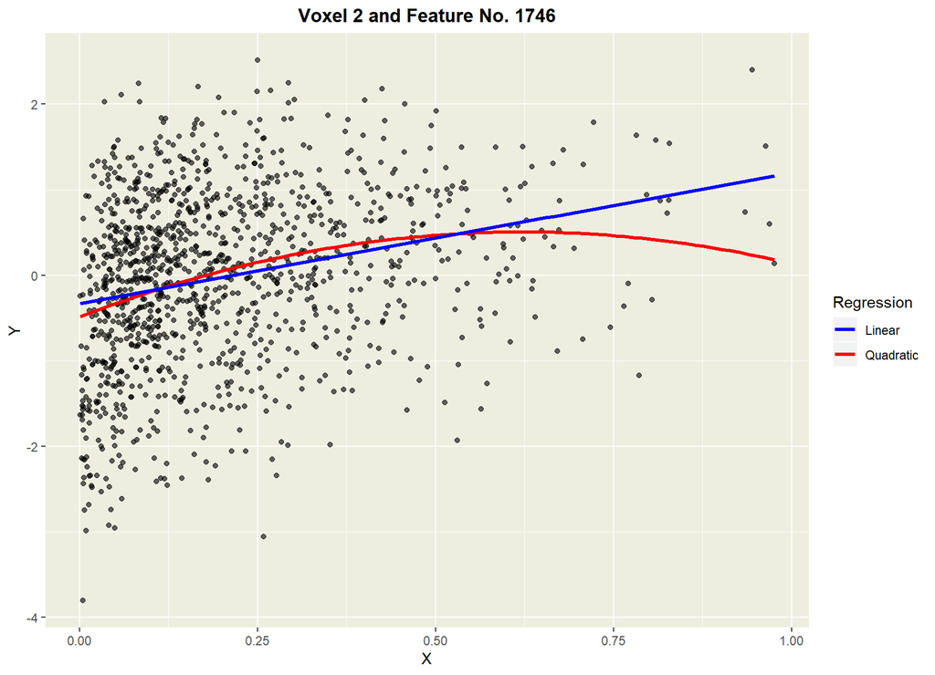

The Linear and Quadratic Regressions have similar results (visually) but we’re going to check it formally by comparing the MSE on the *test* data of Linear and Quadratic Regression.

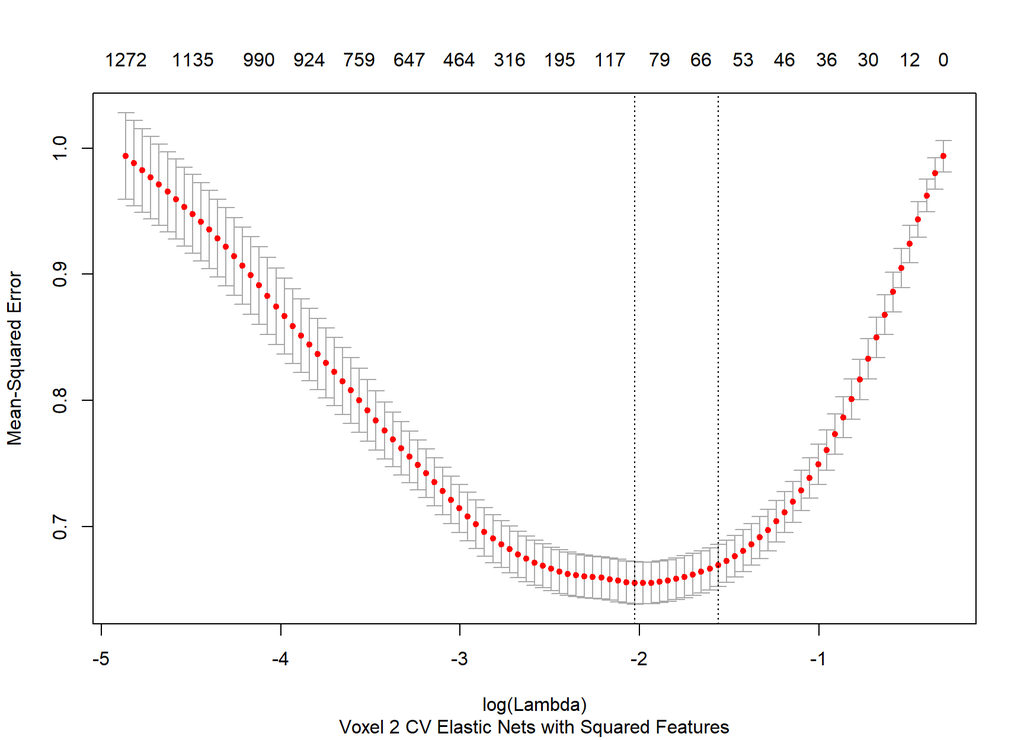

The *test* MSE of the Linear Regression is 0.664589 and the *test* MSE of the Quadratic Regression is 0.6598532 which imply that a Quadratic Regression may have a better out of sample accuracy.

**Fourth** we’re going to compare the *test* images with the lowest and highest *Voxel 2* predictions which can help us understand the difference between the images and understand the data.

For the images themselves:

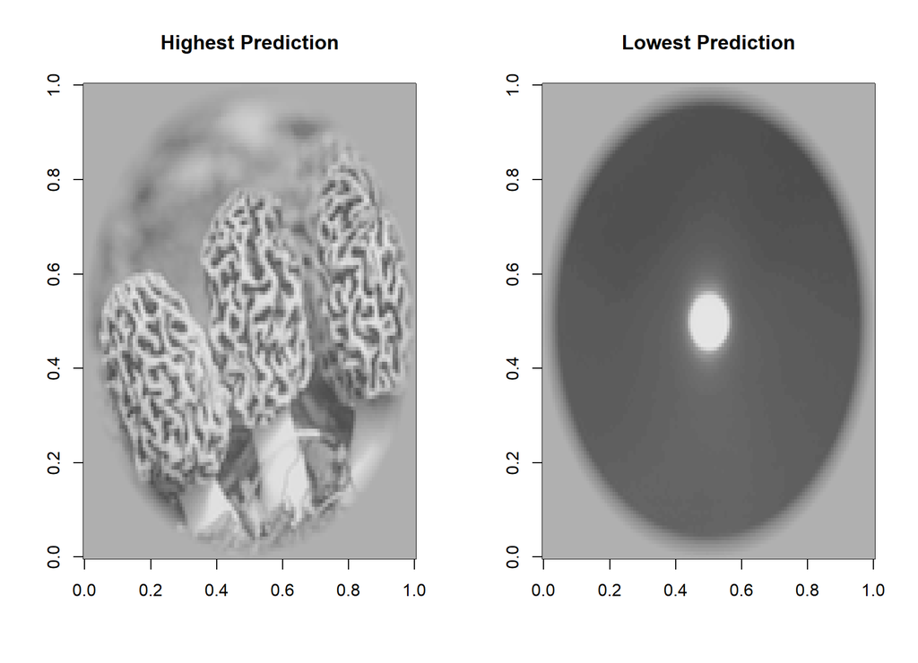

We can see that the highest prediction image has a lot more complexity and different aspect in compare to the lowest prediction one. That may imply an association between specific image complexity and *Voxel 2* activation as estimated by the fMRI test. If out conclusion is correct and the highest prediction image has more complexity we expect that the Features values will be different than the lowest prediction image, lets compare it:

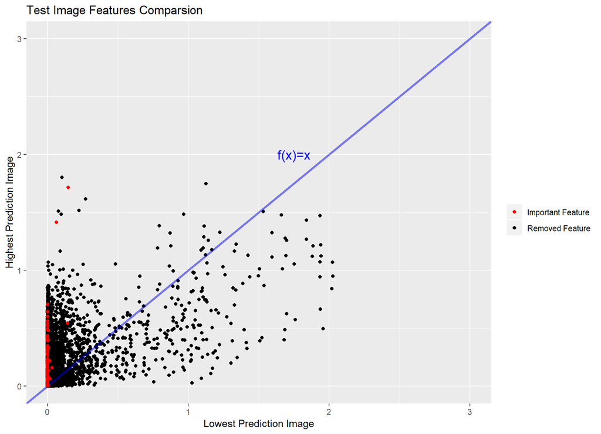

The above plot support our conclusion - almost all important Features (which is the non-zero coefficient Features) with zero values at the lowest prediction image have non-zero values at the highest prediction image which imply that almost all the important features, according to our model, are non-existing at the lowest prediction image.

## Conclusions

After analyzing the best results we reached a few conclusions about our model fit:

1. Quadratic Regression may have a better fit than Linear Regression.
2. Most of the features excluded from the final model because of the *Elastic Nets* Regularization.
3. Voxel 2 associated with specific complex feature that doesn’t exist at all the images.

Moving forward we’re going to predict the *Validation* data by fitting a Quadratic Regression with balanced *Elastic Nets* Regularization model.